# Taxi Fare Prediction

```python
!pip3 install xgboost
```

```python
#packages for numeric + Dataframes
import numpy as np
import pandas as pd

#packages for visualization
import seaborn as sns
import matplotlib.pyplot as plt

#packages for date conversions for calculating trip duration
from datetime import datetime
from datetime import date
from datetime import timedelta

#packages for Regression analysis
from sklearn.model_selection import GridSearchCV, train_test_split
from sklearn.metrics import roc_auc_score, roc_curve
from sklearn.metrics import accuracy_score, precision_score, recall_score,\
f1_score, confusion_matrix, ConfusionMatrixDisplay, RocCurveDisplay,\
mean_absolute_error, r2_score,mean_squared_error
from sklearn.preprocessing import StandardScaler
from sklearn.linear_model import LinearRegression

#packages for Machine Learning
from sklearn.ensemble import RandomForestClassifier
from xgboost import XGBClassifier

# This is the function that helps plot feature importance
from xgboost import plot_importance
```

# Data Load : Load Taxi fare prices into a dataframe

```python
df0 = pd.read_csv("E:/Google Analytics/Automatidata.csv")

df = df0.copy()

df.head()
```

|  | Unnamed: 0 | VendorID | tpep_pickup_datetime | tpep_dropoff_datetime | passenger_count | trip_distance | RatecodeID | store_and_fwd_flag | PULocationID | DOLocationID | payment_type | fare_amount | extra | mta_tax | tip_amount | tolls_amount | improvement_surcharge | total_amount | Unnamed: 18 | Unnamed: 19 |
| --- | --- | --- | --- | --- | --- | --- | --- | --- | --- | --- | --- | --- | --- | --- | --- | --- | --- | --- | --- | --- |
| 0 | 24870114 | 2 | 3/25/2017 8:55 | 3/25/2017 9:09 | 6 | 3.34 | 1 | N | 100 | 231 | 1 | 13.0 | 0.0 | 0.5 | 2.76 | 0.0 | 0.3 | 16.56 | NaN | NaN |
| 1 | 35634249 | 1 | 4/11/2017 14:53 | 4/11/2017 15:19 | 1 | 1.80 | 1 | N | 186 | 43 | 1 | 16.0 | 0.0 | 0.5 | 4.00 | 0.0 | 0.3 | 20.80 | NaN | NaN |
| 2 | 106203690 | 1 | 12/15/2017 7:26 | 12/15/2017 7:34 | 1 | 1.00 | 1 | N | 262 | 236 | 1 | 6.5 | 0.0 | 0.5 | 1.45 | 0.0 | 0.3 | 8.75 | NaN | NaN |
| 3 | 38942136 | 2 | 5/7/2017 13:17 | 5/7/2017 13:48 | 1 | 3.70 | 1 | N | 188 | 97 | 1 | 20.5 | 0.0 | 0.5 | 6.39 | 0.0 | 0.3 | 27.69 | NaN | NaN |
| 4 | 30841670 | 2 | 4/15/2017 23:32 | 4/15/2017 23:49 | 1 | 4.37 | 1 | N | 4 | 112 | 2 | 16.5 | 0.5 | 0.5 | 0.00 | 0.0 | 0.3 | 17.80 | NaN | NaN |

```python
df.shape
```

```
(22699, 20)
```

```python
df.columns
```

```
Index(['Unnamed: 0', 'VendorID', 'tpep_pickup_datetime',
       'tpep_dropoff_datetime', 'passenger_count', 'trip_distance',
       'RatecodeID', 'store_and_fwd_flag', 'PULocationID', 'DOLocationID',
       'payment_type', 'fare_amount', 'extra', 'mta_tax', 'tip_amount',
       'tolls_amount', 'improvement_surcharge', 'total_amount', 'Unnamed: 18',
       'Unnamed: 19'],
      dtype='object')
```

```python
df.info()
```

```
<class 'pandas.core.frame.DataFrame'>
RangeIndex: 22699 entries, 0 to 22698
Data columns (total 20 columns):
 #   Column                 Non-Null Count  Dtype
---  ------                 --------------  -----
 0   Unnamed: 0             22699 non-null  int64
 1   VendorID               22699 non-null  int64
 2   tpep_pickup_datetime   22699 non-null  object
 3   tpep_dropoff_datetime  22699 non-null  object
 4   passenger_count        22699 non-null  int64
 5   trip_distance          22699 non-null  float64
 6   RatecodeID             22699 non-null  int64
 7   store_and_fwd_flag     22699 non-null  object
 8   PULocationID           22699 non-null  int64
 9   DOLocationID           22699 non-null  int64
 10  payment_type           22699 non-null  int64
 11  fare_amount            22699 non-null  float64
 12  extra                  22699 non-null  float64
 13  mta_tax                22699 non-null  float64
 14  tip_amount             22699 non-null  float64
 15  tolls_amount           22699 non-null  float64
 16  improvement_surcharge  22699 non-null  float64
 17  total_amount           22699 non-null  float64
 18  Unnamed: 18            0 non-null      float64
 19  Unnamed: 19            0 non-null      float64
dtypes: float64(10), int64(7), object(3)
memory usage: 3.5+ MB
```

# Data Cleaning : Handel NA and Duplicate value

```python
df.isnull().sum()
```

```
Unnamed: 0                   0
VendorID                     0
tpep_pickup_datetime         0
tpep_dropoff_datetime        0
passenger_count              0
trip_distance                0
RatecodeID                   0
store_and_fwd_flag           0
PULocationID                 0
DOLocationID                 0
payment_type                 0
fare_amount                  0
extra                        0
mta_tax                      0
tip_amount                   0
tolls_amount                 0
improvement_surcharge        0
total_amount                 0
Unnamed: 18              22699
Unnamed: 19              22699
dtype: int64
```

```python
df.duplicated().sum()
```

```
0
```

```python
df = df.drop(columns=['Unnamed: 18','Unnamed: 19'], axis=1)
```

```python
df.info()
```

```
<class 'pandas.core.frame.DataFrame'>
RangeIndex: 22699 entries, 0 to 22698
Data columns (total 18 columns):
 #   Column                 Non-Null Count  Dtype
---  ------                 --------------  -----
 0   Unnamed: 0             22699 non-null  int64
 1   VendorID               22699 non-null  int64
 2   tpep_pickup_datetime   22699 non-null  object
 3   tpep_dropoff_datetime  22699 non-null  object
 4   passenger_count        22699 non-null  int64
 5   trip_distance          22699 non-null  float64
 6   RatecodeID             22699 non-null  int64
 7   store_and_fwd_flag     22699 non-null  object
 8   PULocationID           22699 non-null  int64
 9   DOLocationID           22699 non-null  int64
 10  payment_type           22699 non-null  int64
 11  fare_amount            22699 non-null  float64
 12  extra                  22699 non-null  float64
 13  mta_tax                22699 non-null  float64
 14  tip_amount             22699 non-null  float64
 15  tolls_amount           22699 non-null  float64
 16  improvement_surcharge  22699 non-null  float64
 17  total_amount           22699 non-null  float64
dtypes: float64(8), int64(7), object(3)
memory usage: 3.1+ MB
```

# Feature Engineering

As we see tpep_pickup_datetime and tpep_dropoff_datetime columns type is object so we need to change it to datetime format

```python
df['tpep_pickup_datetime'] = pd.to_datetime(df['tpep_pickup_datetime'])

df['tpep_dropoff_datetime'] = pd.to_datetime(df['tpep_dropoff_datetime'])
```

Use the feature engineering and create one new column duration

```python
df['duration'] = (df['tpep_dropoff_datetime'] - df['tpep_pickup_datetime']) / np.timedelta64(1 ,'m')
```

```python
df['duration'].head()
```

```
0    14.0
1    26.0
2     8.0
3    31.0
4    17.0
Name: duration, dtype: float64
```

# Find and remove the outliers

First we use describe function to see what are columns which might have any outliers

```python
df.describe()
```

|  | Unnamed: 0 | VendorID | passenger_count | trip_distance | RatecodeID | PULocationID | DOLocationID | payment_type | fare_amount | extra | mta_tax | tip_amount | tolls_amount | improvement_surcharge | total_amount | duration |
| --- | --- | --- | --- | --- | --- | --- | --- | --- | --- | --- | --- | --- | --- | --- | --- | --- |
| count | 2.269900e+04 | 22699.000000 | 22699.000000 | 22699.000000 | 22699.000000 | 22699.000000 | 22699.000000 | 22699.000000 | 22699.000000 | 22699.000000 | 22699.000000 | 22699.000000 | 22699.000000 | 22699.000000 | 22699.000000 | 22699.000000 |
| mean | 5.675849e+07 | 1.556236 | 1.642319 | 2.913313 | 1.043394 | 162.412353 | 161.527997 | 1.336887 | 13.026629 | 0.333275 | 0.497445 | 1.835781 | 0.312542 | 0.299551 | 16.310502 | 17.008723 |
| std | 3.274493e+07 | 0.496838 | 1.285231 | 3.653171 | 0.708391 | 66.633373 | 70.139691 | 0.496211 | 13.243791 | 0.463097 | 0.039465 | 2.800626 | 1.399212 | 0.015673 | 16.097295 | 61.996560 |
| min | 1.212700e+04 | 1.000000 | 0.000000 | 0.000000 | 1.000000 | 1.000000 | 1.000000 | 1.000000 | -120.000000 | -1.000000 | -0.500000 | 0.000000 | 0.000000 | -0.300000 | -120.300000 | -17.000000 |
| 25% | 2.852056e+07 | 1.000000 | 1.000000 | 0.990000 | 1.000000 | 114.000000 | 112.000000 | 1.000000 | 6.500000 | 0.000000 | 0.500000 | 0.000000 | 0.000000 | 0.300000 | 8.750000 | 7.000000 |
| 50% | 5.673150e+07 | 2.000000 | 1.000000 | 1.610000 | 1.000000 | 162.000000 | 162.000000 | 1.000000 | 9.500000 | 0.000000 | 0.500000 | 1.350000 | 0.000000 | 0.300000 | 11.800000 | 11.000000 |
| 75% | 8.537452e+07 | 2.000000 | 2.000000 | 3.060000 | 1.000000 | 233.000000 | 233.000000 | 2.000000 | 14.500000 | 0.500000 | 0.500000 | 2.450000 | 0.000000 | 0.300000 | 17.800000 | 18.000000 |
| max | 1.134863e+08 | 2.000000 | 6.000000 | 33.960000 | 99.000000 | 265.000000 | 265.000000 | 4.000000 | 999.990000 | 4.500000 | 0.500000 | 200.000000 | 19.100000 | 0.300000 | 1200.290000 | 1440.000000 |

After seeing the description , the below columns might have a outliers after comparing minimun , maximum, mean & 75% of value

```
1.trip_distance
2.fare_amount
3. total_amount
4. duration
```

```python
df['trip_distance'].sort_values(ascending=False).head(10)
```

```
9280     33.96
13861    33.92
6064     32.72
10291    31.95
29       30.83
18130    30.50
5792     30.33
15350    28.23
10302    28.20
2592     27.97
Name: trip_distance, dtype: float64
```

```python
df['trip_distance'].sort_values(ascending=False).tail(10)
```

```
13359    0.0
5588     0.0
20931    0.0
19712    0.0
13827    0.0
2440     0.0
15916    0.0
1350     0.0
246      0.0
17788    0.0
Name: trip_distance, dtype: float64
```

Ideally trip_distance can never be zero but it might possible that a customer book the taxi but later he/she cancelled ride after starting.

But we have to sure after comparing distance and total amount column

```python
df_sorted_trip_distance = df.sort_values(by='trip_distance',ascending=False)

df_sorted_trip_distance[['trip_distance','total_amount','fare_amount','duration']].head(10)
```

|  | trip_distance | total_amount | fare_amount | duration |
| --- | --- | --- | --- | --- |
| 9280 | 33.96 | 150.30 | 150.00 | 39.0 |
| 13861 | 33.92 | 258.21 | 200.01 | 60.0 |
| 6064 | 32.72 | 179.06 | 107.00 | 67.0 |
| 10291 | 31.95 | 131.80 | 131.00 | 37.0 |
| 29 | 30.83 | 111.38 | 80.00 | 210.0 |
| 18130 | 30.50 | 119.31 | 90.50 | 87.0 |
| 5792 | 30.33 | 73.20 | 52.00 | 63.0 |
| 15350 | 28.23 | 62.96 | 52.00 | 50.0 |
| 10302 | 28.20 | 70.27 | 52.00 | 52.0 |
| 2592 | 27.97 | 63.06 | 52.00 | 50.0 |

```python
df_sorted_trip_distance[['trip_distance','total_amount','fare_amount','duration']].tail(10)
```

|  | trip_distance | total_amount | fare_amount | duration |
| --- | --- | --- | --- | --- |
| 13359 | 0.0 | 111.95 | 75.0 | 0.0 |
| 5588 | 0.0 | 9.50 | 2.5 | 0.0 |
| 20931 | 0.0 | 4.30 | 2.5 | 0.0 |
| 19712 | 0.0 | 4.25 | 2.5 | 0.0 |
| 13827 | 0.0 | 3.95 | 2.5 | 0.0 |
| 2440 | 0.0 | 6.80 | 5.5 | 0.0 |
| 15916 | 0.0 | 10.30 | 8.5 | 13.0 |
| 1350 | 0.0 | 3.96 | 2.5 | 0.0 |
| 246 | 0.0 | 3.80 | 2.5 | 1.0 |
| 17788 | 0.0 | 3.80 | 2.5 | 1.0 |

As we see, for the first top 10 data , distance and total_amount is not proportional but it depends upon verious factors like pickup location and booking time so we need to investigate more.

For the last 10 data, we find some abnormality between tip_distance, total_amount and duration.

For better analysis we have to create box-plot and hisogram for this column.

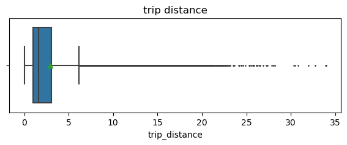

```python
# Create box plot of trip_distance
plt.figure(figsize=(7,2))
plt.title('trip distance')
sns.boxplot(data= df, x=df['trip_distance'],
            fliersize=1,
            showmeans=True
           )
plt.show()
```

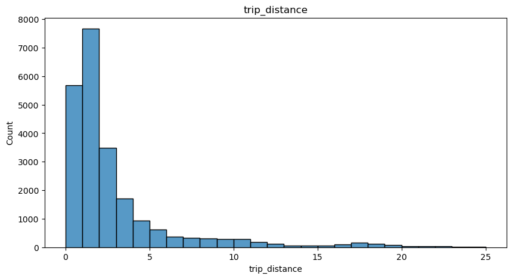

```python
# Create histogram of trip_distance
plt.figure(figsize=(10,5))
sns.histplot(df['trip_distance'], bins=range(0,26,1))
plt.title('trip_distance')
plt.show()
```

We see there is some outlier that is present in trip_amount column, we first find the outliers for all four columns then we remove all of it

```python
df['total_amount'].sort_values(ascending=False).head(10)
```

```
8476     1200.29
20312     450.30
13861     258.21
12511     233.74
15474     211.80
6064      179.06
16379     157.06
3582      152.30
11269     151.82
9280      150.30
Name: total_amount, dtype: float64
```

```python
df['total_amount'].sort_values(ascending=False).tail(10)
```

```
5448      -4.3
4423      -4.3
10281     -4.3
8204      -4.8
20317     -4.8
11204     -5.3
14714     -5.3
17602     -5.8
20698     -5.8
12944   -120.3
Name: total_amount, dtype: float64
```

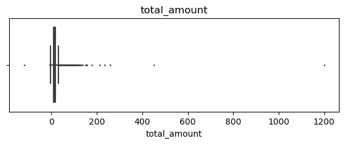

```python
# Create box plot of total_amount

plt.figure(figsize=(7,2))
plt.title('total_amount')
sns.boxplot(data=df, x=df['total_amount'], fliersize=1)
plt.show()
```

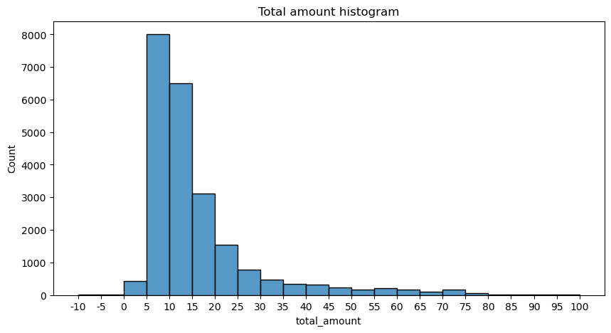

```python
# Create histogram of total_amount
plt.figure(figsize=(10,5))
ax = sns.histplot(df['total_amount'], bins=range(-10,101,5))
ax.set_xticks(range(-10,101,5))# it's used to set the range customized by default it's from zero
ax.set_xticklabels(range(-10,101,5))#it's used for labeling item
plt.title('Total amount histogram');
```

```python
df['fare_amount'].sort_values(ascending=False).head(10)
```

```
8476     999.99
20312    450.00
13861    200.01
15474    200.00
12511    175.00
3582     152.00
9280     150.00
16379    140.00
10291    131.00
11269    120.00
Name: fare_amount, dtype: float64
```

```python
df['fare_amount'].sort_values(ascending=False).tail(10)
```

```
18565     -3.0
4423      -3.0
8204      -3.5
20317     -3.5
5448      -3.5
14714     -4.0
17602     -4.0
11204     -4.5
20698     -4.5
12944   -120.0
Name: fare_amount, dtype: float64
```

Fare amount can never be negative, we need to future investigate using visualization.

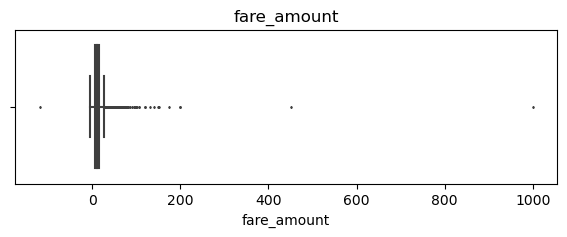

```python
# Create box plot of total_amount

plt.figure(figsize=(7,2))
plt.title('fare_amount')
sns.boxplot(data=df, x=df['fare_amount'], fliersize=1)
plt.show()
```

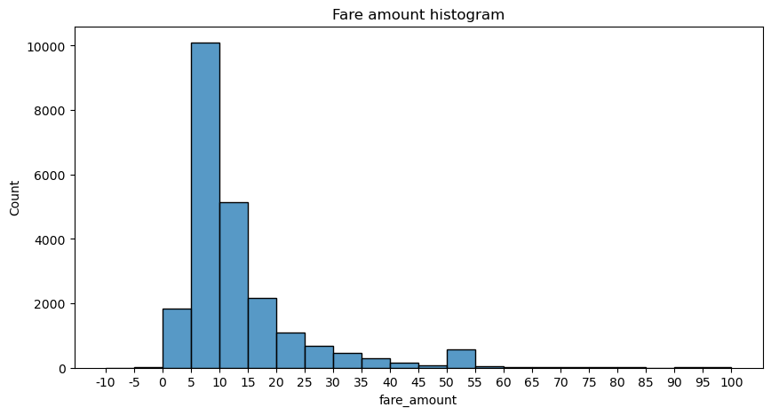

```python
# Create histogram of total_amount
plt.figure(figsize=(10,5))
ax = sns.histplot(df['fare_amount'], bins=range(-10,101,5))
ax.set_xticks(range(-10,101,5))# it's used to set the range customized by default it's from zero
ax.set_xticklabels(range(-10,101,5))#it's used for labeling item
plt.title('Fare amount histogram');
```

```python
df['duration'].sort_values(ascending=False).head(10)
```

```
15579    1440.0
924      1440.0
14998    1439.0
22638    1439.0
21366    1438.0
15163    1438.0
7939     1438.0
6751     1438.0
6493     1437.0
18650    1437.0
Name: duration, dtype: float64
```

```python
df['duration'].sort_values(ascending=False).tail(10)
```

```
5195      0.0
11007     0.0
13494     0.0
19838     0.0
13970     0.0
20549     0.0
8197      0.0
4171      0.0
5798      0.0
9356    -17.0
Name: duration, dtype: float64
```

Duration can never be negative, we have future investigate using visualization

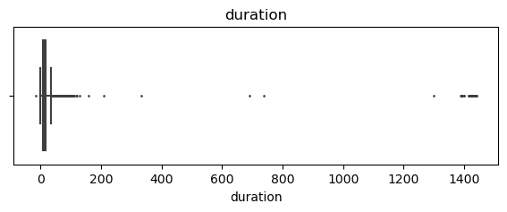

```python
# Create box plot of total_amount

plt.figure(figsize=(7,2))
plt.title('duration')
sns.boxplot(data=df, x=df['duration'], fliersize=1)
plt.show()
```

As we see in visualization , there are some outlier present so we need to remove it for making a prediction model so we create one function for removing outlier

```python
def outlier_imputer(col_list,iqr_factor):

    for col in col_list:
        #Reassign minimum to zero
        df.loc[df[col]<0, col] =0

        #calculate upper threshold
        q3 = df[col].quantile(0.75)
        q1 = df[col].quantile(0.25)

        iqr = q3 - q1

        upper_threshold = q3 + (iqr_factor*iqr)

        #print the upper threshold
        print("upper threshold :",upper_threshold)

        #Reassign the values which is above the upper limit
        df.loc[df[col]>upper_threshold , col] = upper_threshold

        print(df[col].describe())
```

```python
outlier_imputer(['total_amount'],6)
```

```
upper threshold : 72.10000000000001
count    22699.000000
mean        16.124719
std         12.905021
min          0.000000
25%          8.750000
50%         11.800000
75%         17.800000
max         72.100000
Name: total_amount, dtype: float64
```

```python
outlier_imputer(['fare_amount'],6)
```

```
upper threshold : 62.5
count    22699.000000
mean        12.897913
std         10.541137
min          0.000000
25%          6.500000
50%          9.500000
75%         14.500000
max         62.500000
Name: fare_amount, dtype: float64
```

```python
outlier_imputer(['trip_distance'],6)
```

```
upper threshold : 15.480000000000002
count    22699.000000
mean         2.823424
std          3.252029
min          0.000000
25%          0.990000
50%          1.610000
75%          3.060000
max         15.480000
Name: trip_distance, dtype: float64
```

```python
outlier_imputer(['duration'],6)
```

```
upper threshold : 84.0
count    22699.000000
mean        14.439226
std         11.855667
min          0.000000
25%          7.000000
50%         11.000000
75%         18.000000
max         84.000000
Name: duration, dtype: float64
```

# Feature Enginnering

We have to create a mean_distance column

when deployed, the model will not know the duration of a trip until after trip occurs, so you cannot train a model using that feature. However here i used the statistics of trips you do know to generalize about ones i do not know. In this step, create a column called mean_distance that captures the mean distance for each group of trips that share pickup and dropoff points.

Begin by creating a helper column called pickup_dropoff, which contains the unique combination of pickup and dropoff location IDs for each row.

```python
df['pickup_dropoff'] = df['PULocationID'].astype(str) +' '+ df['DOLocationID'].astype(str)

df['pickup_dropoff'].head()
```

```
0    100 231
1     186 43
2    262 236
3     188 97
4      4 112
Name: pickup_dropoff, dtype: object
```

```python
grouped = df.groupby('pickup_dropoff').mean(numeric_only=True)[['trip_distance']]

grouped.head(5)
```

| pickup_dropoff | trip_distance |
| --- | --- |
| 1 1 | 2.433333 |
| 10 148 | 15.480000 |
| 100 1 | 15.480000 |
| 100 100 | 0.253333 |
| 100 107 | 1.180000 |

```python
grouped_dict = grouped.to_dict()
```

```python
grouped_dict = grouped_dict['trip_distance']
```

```python
df['mean_distance'] = df['pickup_dropoff']

df['mean_distance'] = df['mean_distance'].map(grouped_dict)

df.head()
```

|  | Unnamed: 0 | VendorID | tpep_pickup_datetime | tpep_dropoff_datetime | passenger_count | trip_distance | RatecodeID | store_and_fwd_flag | PULocationID | DOLocationID | ... | fare_amount | extra | mta_tax | tip_amount | tolls_amount | improvement_surcharge | total_amount | duration | pickup_dropoff | mean_distance |
| --- | --- | --- | --- | --- | --- | --- | --- | --- | --- | --- | --- | --- | --- | --- | --- | --- | --- | --- | --- | --- | --- |
| 0 | 24870114 | 2 | 2017-03-25 08:55:00 | 2017-03-25 09:09:00 | 6 | 3.34 | 1 | N | 100 | 231 | ... | 13.0 | 0.0 | 0.5 | 2.76 | 0.0 | 0.3 | 16.56 | 14.0 | 100 231 | 3.521667 |
| 1 | 35634249 | 1 | 2017-04-11 14:53:00 | 2017-04-11 15:19:00 | 1 | 1.80 | 1 | N | 186 | 43 | ... | 16.0 | 0.0 | 0.5 | 4.00 | 0.0 | 0.3 | 20.80 | 26.0 | 186 43 | 3.108889 |
| 2 | 106203690 | 1 | 2017-12-15 07:26:00 | 2017-12-15 07:34:00 | 1 | 1.00 | 1 | N | 262 | 236 | ... | 6.5 | 0.0 | 0.5 | 1.45 | 0.0 | 0.3 | 8.75 | 8.0 | 262 236 | 0.881429 |
| 3 | 38942136 | 2 | 2017-05-07 13:17:00 | 2017-05-07 13:48:00 | 1 | 3.70 | 1 | N | 188 | 97 | ... | 20.5 | 0.0 | 0.5 | 6.39 | 0.0 | 0.3 | 27.69 | 31.0 | 188 97 | 3.700000 |
| 4 | 30841670 | 2 | 2017-04-15 23:32:00 | 2017-04-15 23:49:00 | 1 | 4.37 | 1 | N | 4 | 112 | ... | 16.5 | 0.5 | 0.5 | 0.00 | 0.0 | 0.3 | 17.80 | 17.0 | 4 112 | 4.435000 |

5 rows × 21 columns

Same way we have to create mean_duration column

```python
grouped_d = df.groupby('pickup_dropoff').mean(numeric_only=True)[['duration']]

grouped_d.head(5)
```

| pickup_dropoff | duration |
| --- | --- |
| 1 1 | 0.000000 |
| 10 148 | 69.000000 |
| 100 1 | 48.000000 |
| 100 100 | 3.000000 |
| 100 107 | 11.333333 |

```python
grouped_dictd = grouped_d.to_dict()
```

```python
grouped_dictd = grouped_dictd['duration']
```

```python
df['mean_duration'] = df['pickup_dropoff']

df['mean_duration'] = df['mean_duration'].map(grouped_dictd)

df.head()
```

|  | Unnamed: 0 | VendorID | tpep_pickup_datetime | tpep_dropoff_datetime | passenger_count | trip_distance | RatecodeID | store_and_fwd_flag | PULocationID | DOLocationID | ... | extra | mta_tax | tip_amount | tolls_amount | improvement_surcharge | total_amount | duration | pickup_dropoff | mean_distance | mean_duration |
| --- | --- | --- | --- | --- | --- | --- | --- | --- | --- | --- | --- | --- | --- | --- | --- | --- | --- | --- | --- | --- | --- |
| 0 | 24870114 | 2 | 2017-03-25 08:55:00 | 2017-03-25 09:09:00 | 6 | 3.34 | 1 | N | 100 | 231 | ... | 0.0 | 0.5 | 2.76 | 0.0 | 0.3 | 16.56 | 14.0 | 100 231 | 3.521667 | 23.000000 |
| 1 | 35634249 | 1 | 2017-04-11 14:53:00 | 2017-04-11 15:19:00 | 1 | 1.80 | 1 | N | 186 | 43 | ... | 0.0 | 0.5 | 4.00 | 0.0 | 0.3 | 20.80 | 26.0 | 186 43 | 3.108889 | 24.333333 |
| 2 | 106203690 | 1 | 2017-12-15 07:26:00 | 2017-12-15 07:34:00 | 1 | 1.00 | 1 | N | 262 | 236 | ... | 0.0 | 0.5 | 1.45 | 0.0 | 0.3 | 8.75 | 8.0 | 262 236 | 0.881429 | 7.257143 |
| 3 | 38942136 | 2 | 2017-05-07 13:17:00 | 2017-05-07 13:48:00 | 1 | 3.70 | 1 | N | 188 | 97 | ... | 0.0 | 0.5 | 6.39 | 0.0 | 0.3 | 27.69 | 31.0 | 188 97 | 3.700000 | 31.000000 |
| 4 | 30841670 | 2 | 2017-04-15 23:32:00 | 2017-04-15 23:49:00 | 1 | 4.37 | 1 | N | 4 | 112 | ... | 0.5 | 0.5 | 0.00 | 0.0 | 0.3 | 17.80 | 17.0 | 4 112 | 4.435000 | 14.500000 |

5 rows × 22 columns

Create rush_hour columns:

We have to find when demand is more compare to others time, after analysis of data we found weekdays(except sat and sun) in between 6 to 10 and 16 to 20 the taxi demand is more.

```python
df['rush_hour'] = df['tpep_pickup_datetime'].dt.hour
```

```python
df['day'] = df['tpep_pickup_datetime'].dt.day_name().str.lower()
```

```python
df['day'].unique()
```

```
array(['saturday', 'tuesday', 'friday', 'sunday', 'wednesday', 'monday',
       'thursday'], dtype=object)
```

```python
df.loc[df['day'].isin(['saturday','sunday']), 'rush_hour'] = 0
```

Create a function for define value which is with in the specific time range

```python
def rush_hour(hour):
    if 6 <= hour['rush_hour'] <10 or 16<= hour['rush_hour'] <20:
        val=1
    else:
        val=0

    return val
```

```python
df['rush_hour'] = df.apply(rush_hour , axis=1)

df['rush_hour'].unique()
```

```
array([0, 1], dtype=int64)
```

Create a scatterplot to check relationship between mean_duration and fare_amount

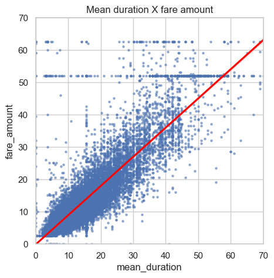

```python
sns.set(style='whitegrid')

f = plt.figure()

f.set_figwidth(5)

f.set_figheight(5)

sns.regplot(x=df['mean_duration'], y=df['fare_amount'],
               scatter_kws={'alpha':0.5, 's':5},
                line_kws={'color':'red'}
               )

plt.ylim(0,70)

plt.xlim(0,70)

plt.title('Mean duration X fare amount')

plt.show()
```

```python
df[df['fare_amount']>50]['fare_amount'].value_counts().head()
```

```
52.0    514
62.5     84
59.0      9
50.5      9
57.5      8
Name: fare_amount, dtype: int64
```

As we see, most number of point is present in fare_amount 52 so it needs to check all columns

```python
pd.set_option('display.max_columns',None)

df[df['fare_amount']==52].head()
```

|  | Unnamed: 0 | VendorID | tpep_pickup_datetime | tpep_dropoff_datetime | passenger_count | trip_distance | RatecodeID | store_and_fwd_flag | PULocationID | DOLocationID | payment_type | fare_amount | extra | mta_tax | tip_amount | tolls_amount | improvement_surcharge | total_amount | duration | pickup_dropoff | mean_distance | mean_duration | rush_hour | day |
| --- | --- | --- | --- | --- | --- | --- | --- | --- | --- | --- | --- | --- | --- | --- | --- | --- | --- | --- | --- | --- | --- | --- | --- | --- |
| 11 | 18600059 | 2 | 2017-03-05 19:15:00 | 2017-03-05 19:52:00 | 2 | 15.48 | 2 | N | 236 | 132 | 1 | 52.0 | 0.0 | 0.5 | 14.58 | 5.54 | 0.3 | 72.1 | 37.0 | 236 132 | 15.480000 | 39.833333 | 0 | sunday |
| 110 | 47959795 | 1 | 2017-06-03 14:24:00 | 2017-06-03 15:31:00 | 1 | 15.48 | 2 | N | 132 | 163 | 1 | 52.0 | 0.0 | 0.5 | 0.00 | 0.00 | 0.3 | 52.8 | 67.0 | 132 163 | 15.480000 | 53.000000 | 0 | saturday |
| 161 | 95729204 | 2 | 2017-11-11 20:16:00 | 2017-11-11 20:17:00 | 1 | 0.23 | 2 | N | 132 | 132 | 2 | 52.0 | 0.0 | 0.5 | 0.00 | 0.00 | 0.3 | 52.8 | 1.0 | 132 132 | 1.941034 | 3.068966 | 0 | saturday |
| 247 | 103404868 | 2 | 2017-12-06 23:37:00 | 2017-12-07 00:06:00 | 1 | 15.48 | 2 | N | 132 | 79 | 2 | 52.0 | 0.0 | 0.5 | 0.00 | 0.00 | 0.3 | 52.8 | 29.0 | 132 79 | 15.480000 | 47.000000 | 0 | wednesday |
| 379 | 80479432 | 2 | 2017-09-24 23:45:00 | 2017-09-25 00:15:00 | 1 | 15.48 | 2 | N | 132 | 234 | 1 | 52.0 | 0.0 | 0.5 | 14.64 | 5.76 | 0.3 | 72.1 | 30.0 | 132 234 | 15.480000 | 49.600000 | 0 | sunday |

```python
ratecode = df[df['fare_amount']==52][['RatecodeID','PULocationID']]

ratecode['PULocationID'].value_counts()
```

```
132    292
264     15
163     13
170     13
233      9
      ...
265      1
261      1
145      1
130      1
125      1
Name: PULocationID, Length: 62, dtype: int64
```

```python
ratecode['RatecodeID'].value_counts()
```

```
2    513
1      1
Name: RatecodeID, dtype: int64
```

As we see, where fare_amount is 52, It may be because of Pickup Location or RatecodeID so we created data frame where we input ratecodeID and picklocation for whose fare_amount is 52.

# Data Prepartion for Regression Test

```python
df2 = df.copy()

#drop the all less important columns
df2 = df2.drop(['Unnamed: 0', 'tpep_dropoff_datetime', 'tpep_pickup_datetime',
               'trip_distance', 'RatecodeID', 'store_and_fwd_flag', 'PULocationID', 'DOLocationID',
               'payment_type', 'extra', 'mta_tax', 'tip_amount', 'tolls_amount', 'improvement_surcharge',
               'total_amount', 'tpep_dropoff_datetime', 'tpep_pickup_datetime', 'duration',
               'pickup_dropoff', 'day',
               ], axis=1)

df2.info()
```

```
<class 'pandas.core.frame.DataFrame'>
RangeIndex: 22699 entries, 0 to 22698
Data columns (total 6 columns):
 #   Column           Non-Null Count  Dtype
---  ------           --------------  -----
 0   VendorID         22699 non-null  int64
 1   passenger_count  22699 non-null  int64
 2   fare_amount      22699 non-null  float64
 3   mean_distance    22699 non-null  float64
 4   mean_duration    22699 non-null  float64
 5   rush_hour        22699 non-null  int64
dtypes: float64(3), int64(3)
memory usage: 1.0 MB
```

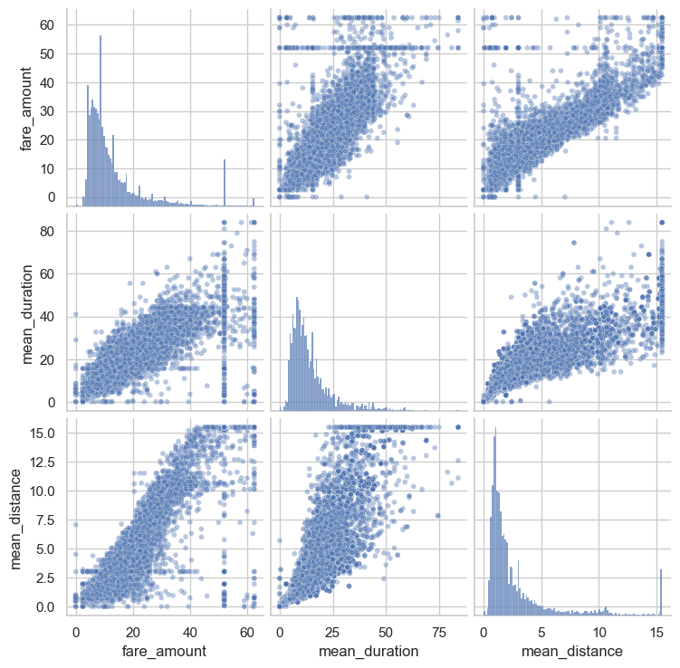

```python
# Create a pairplot to visualize pairwise relationships between variables in the data
sns.pairplot(df2[['fare_amount', 'mean_duration', 'mean_distance']],
             plot_kws={'alpha':0.4, 'size':5},
             );
```

# Check colinearity before modeling

```python
# Create correlation matrix containing pairwise correlation of columns, using pearson correlation coefficient
df2.corr(method='pearson')
```

|  | VendorID | passenger_count | fare_amount | mean_distance | mean_duration | rush_hour |
| --- | --- | --- | --- | --- | --- | --- |
| VendorID | 1.000000 | 0.266463 | 0.001045 | 0.002933 | 0.001894 | -0.002874 |
| passenger_count | 0.266463 | 1.000000 | 0.014942 | 0.014362 | 0.015855 | -0.022035 |
| fare_amount | 0.001045 | 0.014942 | 1.000000 | 0.913404 | 0.859902 | -0.020075 |
| mean_distance | 0.002933 | 0.014362 | 0.913404 | 1.000000 | 0.886441 | -0.044230 |
| mean_duration | 0.001894 | 0.015855 | 0.859902 | 0.886441 | 1.000000 | -0.021897 |
| rush_hour | -0.002874 | -0.022035 | -0.020075 | -0.044230 | -0.021897 | 1.000000 |

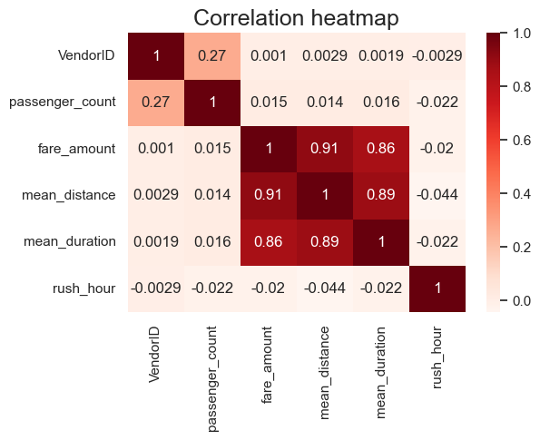

```python
# Create correlation heatmap

plt.figure(figsize=(6,4))
sns.heatmap(df2.corr(method='pearson'), annot=True, cmap='Reds')
plt.title('Correlation heatmap',
          fontsize=18)
plt.show()
```

As they are highly correlated predictor variables can be bad for linear regression model when we want to be able to draw statistical inferences about the data from the model. However, correlated predictor variables can still be used to create an accurate predictor if the prediction itself is more important than using the model as a tool to learn about our data.

This model will predict fare_amount, which will be used as a predictor variable in machine learning models. Therefore, try modeling with both variables even though they are correlated.

```python
# Remove the target column from the features
X = df2.drop(columns=['fare_amount'])

# Set y variable
y = df2[['fare_amount']]

# Display first few rows
X.head()
```

|  | VendorID | passenger_count | mean_distance | mean_duration | rush_hour |
| --- | --- | --- | --- | --- | --- |
| 0 | 2 | 6 | 3.521667 | 23.000000 | 0 |
| 1 | 1 | 1 | 3.108889 | 24.333333 | 0 |
| 2 | 1 | 1 | 0.881429 | 7.257143 | 1 |
| 3 | 2 | 1 | 3.700000 | 31.000000 | 0 |
| 4 | 2 | 1 | 4.435000 | 14.500000 | 0 |

```python
# Convert VendorID to string
X['VendorID'] = X['VendorID'].astype(str)

# Get dummies
X = pd.get_dummies(X, drop_first=True)
X.head()
```

|  | passenger_count | mean_distance | mean_duration | rush_hour | VendorID_2 |
| --- | --- | --- | --- | --- | --- |
| 0 | 6 | 3.521667 | 23.000000 | 0 | 1 |
| 1 | 1 | 3.108889 | 24.333333 | 0 | 0 |
| 2 | 1 | 0.881429 | 7.257143 | 1 | 0 |
| 3 | 1 | 3.700000 | 31.000000 | 0 | 1 |
| 4 | 1 | 4.435000 | 14.500000 | 0 | 1 |

```python
# Create training and testing sets

X_train, X_test, y_train, y_test = train_test_split(X, y, test_size=0.2, random_state=0)
```

As we see, all values are not equal range so we have to Standardize the data using Standardize program so that it can fit in linear regression model

```python
# Standardize the X variables
scaler = StandardScaler().fit(X_train)
X_train_scaled = scaler.transform(X_train)
print('X_train scaled:', X_train_scaled)
```

```
X_train scaled: [[-0.50301524  1.00348588  0.15747652 -0.64893329  0.89286563]
 [-0.50301524 -0.64391805 -0.71224238  1.54099045  0.89286563]
 [ 0.27331093 -0.50735614 -0.56669758 -0.64893329 -1.11998936]
 ...
 [-0.50301524 -0.47699901 -0.66908339 -0.64893329 -1.11998936]
 [-0.50301524 -0.63196235 -0.85719553  1.54099045 -1.11998936]
 [ 1.82596329  0.9667956   1.15144097 -0.64893329  0.89286563]]
```

```python
# Fit your model to the training data
lr=LinearRegression()
lr.fit(X_train_scaled, y_train)
```

```
LinearRegression()
```

# Evalute the model

```python
# Evaluate the model performance on the training data
r_sq = lr.score(X_train_scaled, y_train)
print('Coefficient of determination:', r_sq)
y_pred_train = lr.predict(X_train_scaled)
print('R^2:', r2_score(y_train, y_pred_train))
print('MAE:', mean_absolute_error(y_train, y_pred_train))
print('MSE:', mean_squared_error(y_train, y_pred_train))
print('RMSE:',np.sqrt(mean_squared_error(y_train, y_pred_train)))
```

```
Coefficient of determination: 0.8399388364828184
R^2: 0.8399388364828184
MAE: 2.194172283979019
MSE: 17.879079096050322
RMSE: 4.228366007815587
```

```python
# Scale the X_test data
X_test_scaled = scaler.transform(X_test)
```

```python
# Evaluate the model performance on the testing data
r_sq_test = lr.score(X_test_scaled, y_test)
print('Coefficient of determination:', r_sq_test)
y_pred_test = lr.predict(X_test_scaled)
print('R^2:', r2_score(y_test, y_pred_test))
print('MAE:', mean_absolute_error(y_test,y_pred_test))
print('MSE:', mean_squared_error(y_test, y_pred_test))
print('RMSE:',np.sqrt(mean_squared_error(y_test, y_pred_test)))
```

```
Coefficient of determination: 0.8726130198175095
R^2: 0.8726130198175095
MAE: 2.117549370487915
MSE: 13.852900189202204
RMSE: 3.7219484398903493
```

# Result

```python
# Create a `results` dataframe
results = pd.DataFrame(data={'actual': y_test['fare_amount'],
                             'predicted': y_pred_test.ravel()})
results['residual'] = results['actual'] - results['predicted']
results.head()
```

|  | actual | predicted | residual |
| --- | --- | --- | --- |
| 5818 | 14.0 | 12.571438 | 1.428562 |
| 18134 | 28.0 | 16.476984 | 11.523016 |
| 4655 | 5.5 | 6.496373 | -0.996373 |
| 7378 | 15.5 | 17.037773 | -1.537773 |
| 13914 | 9.5 | 10.395490 | -0.895490 |

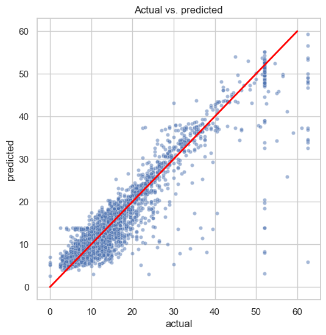

```python
# Create a scatterplot to visualize `predicted` over `actual`
fig, ax = plt.subplots(figsize=(6, 6))
sns.set(style='whitegrid')
sns.scatterplot(x='actual',
                y='predicted',
                data=results,
                s=20,
                alpha=0.5,
                ax=ax
)
plt.plot([0,60], [0,60], c='red', linewidth=2)
plt.title('Actual vs. predicted');
```

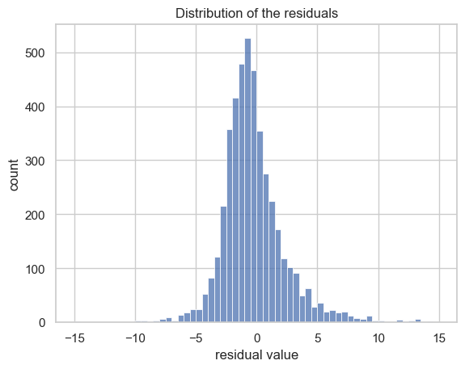

```python
# Visualize the distribution of the `residuals`
sns.histplot(results['residual'], bins=np.arange(-15,15.5,0.5))
plt.title('Distribution of the residuals')
plt.xlabel('residual value')
plt.ylabel('count');
```

```python
results['residual'].mean()
```

```
-0.03781541730087056
```

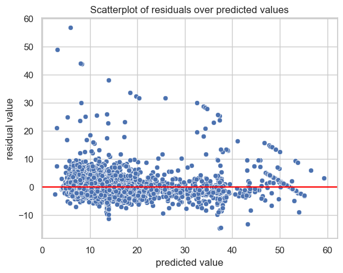

```python
# Create a scatterplot of `residuals` over `predicted`

sns.scatterplot(x='predicted', y='residual', data=results)
plt.axhline(0, c='red')
plt.title('Scatterplot of residuals over predicted values')
plt.xlabel('predicted value')
plt.ylabel('residual value')
plt.show()
```

# Prediction Value

```python
# Get model coefficients
coefficients = pd.DataFrame(lr.coef_, columns=X.columns)
coefficients
```

|  | passenger_count | mean_distance | mean_duration | rush_hour | VendorID_2 |
| --- | --- | --- | --- | --- | --- |
| 0 | 0.018668 | 7.462246 | 2.439108 | 0.153312 | -0.032436 |

```python
# 1. Calculate SD of `mean_distance` in X_train data
print(X_train['mean_distance'].std())

# 2. Divide the model coefficient by the standard deviation
print(7.133867 / X_train['mean_distance'].std())
```

```
3.1889434657099107
2.237062863205035
```

```python
X_scaled = scaler.transform(X)
y_preds_full = lr.predict(X_scaled)
```

```python
# Create a new df containing just the RatecodeID col from the whole dataset
final_preds = df[['RatecodeID']].copy()

# Add a column containing all the predictions
final_preds['y_preds_full'] = y_preds_full

# Impute a prediction of 52 at all rows where RatecodeID == 2
final_preds.loc[final_preds['RatecodeID']==2, 'y_preds_full'] = 52

# Check that it worked
final_preds[final_preds['RatecodeID']==2].head()
```

|  | RatecodeID | y_preds_full |
| --- | --- | --- |
| 11 | 2 | 52.0 |
| 110 | 2 | 52.0 |
| 161 | 2 | 52.0 |
| 247 | 2 | 52.0 |
| 379 | 2 | 52.0 |

```python
final_preds = final_preds['y_preds_full']
print('R^2:', r2_score(y, final_preds))
print('MAE:', mean_absolute_error(y, final_preds))
print('MSE:', mean_squared_error(y, final_preds))
print('RMSE:',np.sqrt(mean_squared_error(y, final_preds)))
```

```
R^2: 0.889497543039046
MAE: 2.027343023826225
MSE: 12.278003134519263
RMSE: 3.5039981641717883
```

```python
# Combine means columns with predictions column
nyc_preds_means = df[['mean_duration', 'mean_distance']].copy()
nyc_preds_means['predicted_fare'] = final_preds

nyc_preds_means.head()
```

|  | mean_duration | mean_distance | predicted_fare |
| --- | --- | --- | --- |
| 0 | 23.000000 | 3.521667 | 16.549445 |
| 1 | 24.333333 | 3.108889 | 15.899582 |
| 2 | 7.257143 | 0.881429 | 6.882911 |
| 3 | 31.000000 | 3.700000 | 18.833812 |
| 4 | 14.500000 | 4.435000 | 16.553548 |

# Use Machine Learning model for tip amount prediction

Merge the new created columns with original data frame

```python
df3 = df0.copy()
```

```python
df3.head()
```

|  | Unnamed: 0 | VendorID | tpep_pickup_datetime | tpep_dropoff_datetime | passenger_count | trip_distance | RatecodeID | store_and_fwd_flag | PULocationID | DOLocationID | payment_type | fare_amount | extra | mta_tax | tip_amount | tolls_amount | improvement_surcharge | total_amount | Unnamed: 18 | Unnamed: 19 |
| --- | --- | --- | --- | --- | --- | --- | --- | --- | --- | --- | --- | --- | --- | --- | --- | --- | --- | --- | --- | --- |
| 0 | 24870114 | 2 | 3/25/2017 8:55 | 3/25/2017 9:09 | 6 | 3.34 | 1 | N | 100 | 231 | 1 | 13.0 | 0.0 | 0.5 | 2.76 | 0.0 | 0.3 | 16.56 | NaN | NaN |
| 1 | 35634249 | 1 | 4/11/2017 14:53 | 4/11/2017 15:19 | 1 | 1.80 | 1 | N | 186 | 43 | 1 | 16.0 | 0.0 | 0.5 | 4.00 | 0.0 | 0.3 | 20.80 | NaN | NaN |
| 2 | 106203690 | 1 | 12/15/2017 7:26 | 12/15/2017 7:34 | 1 | 1.00 | 1 | N | 262 | 236 | 1 | 6.5 | 0.0 | 0.5 | 1.45 | 0.0 | 0.3 | 8.75 | NaN | NaN |
| 3 | 38942136 | 2 | 5/7/2017 13:17 | 5/7/2017 13:48 | 1 | 3.70 | 1 | N | 188 | 97 | 1 | 20.5 | 0.0 | 0.5 | 6.39 | 0.0 | 0.3 | 27.69 | NaN | NaN |
| 4 | 30841670 | 2 | 4/15/2017 23:32 | 4/15/2017 23:49 | 1 | 4.37 | 1 | N | 4 | 112 | 2 | 16.5 | 0.5 | 0.5 | 0.00 | 0.0 | 0.3 | 17.80 | NaN | NaN |

```python
df3.info()
```

```
<class 'pandas.core.frame.DataFrame'>
RangeIndex: 22699 entries, 0 to 22698
Data columns (total 20 columns):
 #   Column                 Non-Null Count  Dtype
---  ------                 --------------  -----
 0   Unnamed: 0             22699 non-null  int64
 1   VendorID               22699 non-null  int64
 2   tpep_pickup_datetime   22699 non-null  object
 3   tpep_dropoff_datetime  22699 non-null  object
 4   passenger_count        22699 non-null  int64
 5   trip_distance          22699 non-null  float64
 6   RatecodeID             22699 non-null  int64
 7   store_and_fwd_flag     22699 non-null  object
 8   PULocationID           22699 non-null  int64
 9   DOLocationID           22699 non-null  int64
 10  payment_type           22699 non-null  int64
 11  fare_amount            22699 non-null  float64
 12  extra                  22699 non-null  float64
 13  mta_tax                22699 non-null  float64
 14  tip_amount             22699 non-null  float64
 15  tolls_amount           22699 non-null  float64
 16  improvement_surcharge  22699 non-null  float64
 17  total_amount           22699 non-null  float64
 18  Unnamed: 18            0 non-null      float64
 19  Unnamed: 19            0 non-null      float64
dtypes: float64(10), int64(7), object(3)
memory usage: 3.5+ MB
```

Check the frequency of mode of payments

```python
df3['payment_type'].value_counts()
```

```
1    15265
2     7267
3      121
4       46
Name: payment_type, dtype: int64
```

As we see mode of payment happened with using 1 or credit card

now check total number of tips provided by each payment type

```python
df3.groupby(['payment_type']).sum()[['tip_amount']]
```

| payment_type | tip_amount |
| --- | --- |
| 1 | 41670.4 |
| 2 | 0.0 |
| 3 | 0.0 |
| 4 | 0.0 |

As we clearly See customer who uses credit card for paying fare , is most likely to provide tip.

So we will create model only those customer uses credit card for paying fare.

```python
df4 = df3[df3['payment_type']==1]
```

# Feature Enginnering

We have to create a target variable which is tip_percentage.

This column will show ratio between tip_amount to total amount mins trip amount

tip_percentage = tip_amount / (total amount - tip_amount)

```python
df4['tip_percent'] = round((df4['tip_amount']/(df4['total_amount']-df4['tip_amount'])),3)

df4['tip_percent'].head()
```

[output not shown]

```
0    0.200
1    0.238
2    0.199
3    0.300
5    0.200
Name: tip_percent, dtype: float64
```

Now we consider customer who tip_percent ratio is more than 0.2 is called generous else not.

```python
df4['generous'] = df4['tip_percent']

df4['generous'] = np.where(df4['tip_percent']>=0.2,1,0)

df4['generous'].head()
```

[output not shown]

```
0    1
1    1
2    0
3    1
5    1
Name: generous, dtype: int32
```

```python
df4['generous'].value_counts(normalize=True)
```

```
1    0.526368
0    0.473632
Name: generous, dtype: float64
```

```python
df4['tpep_pickup_datetime'] = pd.to_datetime(df4['tpep_pickup_datetime'])
df4['tpep_dropoff_datetime'] = pd.to_datetime(df4['tpep_dropoff_datetime'])
```

[output not shown]

As we see there is no imbalance between two classes so there is no need data manipution

Now divided the pickup time into four columns according to their Type

```
   1. am_rush = 6 to 10
   2. daytime =10 to 16
   3.pm_rush =16 to 20
   4. nighttime = 20 to 24 and 0 to 6
```

```python
#create four new columns for each value
df4['am_rush'] = df4['tpep_pickup_datetime'].dt.hour

df4['daytime'] = df4['tpep_pickup_datetime'].dt.hour


df4['pm_rush'] = df4['tpep_pickup_datetime'].dt.hour

df4['nighttime'] = df4['tpep_pickup_datetime'].dt.hour
```

[output not shown]

```python
def am_rush(hours):
    if 6<=hours['am_rush'] <10:
        val =1
    else:
        val =0

    return val
```

```python
df4['am_rush'] = df4.apply(am_rush, axis=1)

df4['am_rush'].head()
```

[output not shown]

```
0    1
1    0
2    1
3    0
5    0
Name: am_rush, dtype: int64
```

```python
def daytime(hours):
    if 10<=hours['daytime'] <16:
        val =1
    else:
        val =0

    return val
```

```python
df4['daytime'] = df4.apply(daytime, axis=1)

df4['daytime'].head()
```

[output not shown]

```
0    0
1    1
2    0
3    1
5    0
Name: daytime, dtype: int64
```

```python
def pm_rush(hours):
    if 16<=hours['pm_rush'] <20:
        val =1
    else:
        val =0

    return val
```

```python
df4['pm_rush'] = df4.apply(pm_rush, axis=1)

df4['pm_rush'].head()
```

[output not shown]

```
0    0
1    0
2    0
3    0
5    0
Name: pm_rush, dtype: int64
```

```python
def nighttime(hours):
    if 20<=hours['nighttime'] <24 or 0<=hours['nighttime']<6:
        val =1
    else:
        val =0

    return val
```

```python
df4['nighttime'] = df4.apply(nighttime, axis=1)
```

[output not shown]

```python
# Drop columns less important columns
drop_cols = ['Unnamed: 0', 'tpep_pickup_datetime', 'tpep_dropoff_datetime',
             'payment_type', 'trip_distance', 'store_and_fwd_flag', 'payment_type',
             'fare_amount', 'extra', 'mta_tax', 'tip_amount', 'tolls_amount',
             'improvement_surcharge', 'total_amount', 'tip_percent','Unnamed: 18','Unnamed: 19']

df4 = df4.drop(drop_cols, axis=1)
df4.info()
```

```
<class 'pandas.core.frame.DataFrame'>
Int64Index: 15265 entries, 0 to 22698
Data columns (total 10 columns):
 #   Column           Non-Null Count  Dtype
---  ------           --------------  -----
 0   VendorID         15265 non-null  int64
 1   passenger_count  15265 non-null  int64
 2   RatecodeID       15265 non-null  int64
 3   PULocationID     15265 non-null  int64
 4   DOLocationID     15265 non-null  int64
 5   generous         15265 non-null  int32
 6   am_rush          15265 non-null  int64
 7   daytime          15265 non-null  int64
 8   pm_rush          15265 non-null  int64
 9   nighttime        15265 non-null  int64
dtypes: int32(1), int64(9)
memory usage: 1.2 MB
```

```python
# Define list of cols to convert to string
cols_to_str = ['RatecodeID', 'PULocationID', 'DOLocationID', 'VendorID']

#  Convert each column to string
for col in cols_to_str:
    df4[col] = df4[col].astype('str')
```

```python
# Convert categoricals to binary
df4 = pd.get_dummies(df4, drop_first=True)
df4.info()
```

```
<class 'pandas.core.frame.DataFrame'>
Int64Index: 15265 entries, 0 to 22698
Columns: 327 entries, passenger_count to DOLocationID_97
dtypes: int32(1), int64(5), uint8(321)
memory usage: 5.4 MB
```

# Isolate the X and Y variables

```python
# Isolate target variable (y)
y = df4['generous']

# Isolate the features (X)
X = df4.drop('generous', axis=1)

# Split into train and test sets
X_train, X_test, y_train, y_test = train_test_split(X, y, stratify=y, test_size=0.2, random_state=42)
```

```python
X.info()
```

```
<class 'pandas.core.frame.DataFrame'>
Int64Index: 15265 entries, 0 to 22698
Columns: 326 entries, passenger_count to DOLocationID_97
dtypes: int64(5), uint8(321)
memory usage: 5.4 MB
```

# Use to check Random forest model

```python
# 1. Instantiate the random forest classifier
rf = RandomForestClassifier(random_state=42)

# 2. Create a dictionary of hyperparameters to tune
cv_params = {'max_depth': [None],
             'max_features': [1.0],
             'max_samples': [0.7],
             'min_samples_leaf': [1],
             'min_samples_split': [2],
             'n_estimators': [300]
             }

# 3. Define a dictionary of scoring metrics to capture
scoring = {'accuracy', 'precision', 'recall', 'f1'}

# 4. Instantiate the GridSearchCV object
rf1 = GridSearchCV(rf, cv_params, scoring=scoring, cv=4, refit='f1')
```

```python
%%time
rf1.fit(X_train, y_train)
```

```
Wall time: 6min 8s
```

```
GridSearchCV(cv=4, estimator=RandomForestClassifier(random_state=42),
             param_grid={'max_depth': [None], 'max_features': [1.0],
                         'max_samples': [0.7], 'min_samples_leaf': [1],
                         'min_samples_split': [2], 'n_estimators': [300]},
             refit='f1', scoring={'recall', 'f1', 'precision', 'accuracy'})
```

Result for RandomForest

```python
# Examine best score
rf1.best_score_
```

```
0.6886070846470285
```

```python
rf1.best_params_
```

```
{'max_depth': None,
 'max_features': 1.0,
 'max_samples': 0.7,
 'min_samples_leaf': 1,
 'min_samples_split': 2,
 'n_estimators': 300}
```

Create a table for result table

```python
def make_results(model_name:str, model_object, metric:str):

    # Create dictionary that maps input metric to actual metric name in GridSearchCV
    metric_dict = {'precision': 'mean_test_precision',
                 'recall': 'mean_test_recall',
                 'f1': 'mean_test_f1',
                 'accuracy': 'mean_test_accuracy',
                 }

    # Get all the results from the CV and put them in a df
    cv_results = pd.DataFrame(model_object.cv_results_)

    # Isolate the row of the df with the max(metric) score
    best_estimator_results = cv_results.iloc[cv_results[metric_dict[metric]].idxmax(), :]

    # Extract Accuracy, precision, recall, and f1 score from that row
    f1 = best_estimator_results.mean_test_f1
    recall = best_estimator_results.mean_test_recall
    precision = best_estimator_results.mean_test_precision
    accuracy = best_estimator_results.mean_test_accuracy

    # Create table of results
    table = pd.DataFrame({'model': [model_name],
                        'precision': [precision],
                        'recall': [recall],
                        'F1': [f1],
                        'accuracy': [accuracy],
                        },
                       )

    return table
```

```python
# Call 'make_results()' on the GridSearch object
results = make_results('RF CV', rf1, 'f1')
results
```

|  | model | precision | recall | F1 | accuracy |
| --- | --- | --- | --- | --- | --- |
| 0 | RF CV | 0.667156 | 0.711886 | 0.688607 | 0.661317 |

Test model in using testing data

```python
# Get scores on test data
rf_preds = rf1.best_estimator_.predict(X_test)
```

```python
def get_test_scores(model_name:str, preds, y_test_data):

    accuracy = accuracy_score(y_test_data, preds)
    precision = precision_score(y_test_data, preds)
    recall = recall_score(y_test_data, preds)
    f1 = f1_score(y_test_data, preds)

    table = pd.DataFrame({'model': [model_name],
                        'precision': [precision],
                        'recall': [recall],
                        'F1': [f1],
                        'accuracy': [accuracy]
                        })

    return table
```

```python
# Get scores on test data
rf_test_scores = get_test_scores('RF test', rf_preds, y_test)
results = pd.concat([results, rf_test_scores], axis=0)
results
```

|  | model | precision | recall | F1 | accuracy |
| --- | --- | --- | --- | --- | --- |
| 0 | RF CV | 0.667156 | 0.711886 | 0.688607 | 0.661317 |
| 0 | RF test | 0.655019 | 0.734910 | 0.692669 | 0.656731 |

# Test the same data using XGBoost model

```python
# 1. Instantiate the XGBoost classifier
xgb = XGBClassifier(objective='binary:logistic', random_state=0)

# 2. Create a dictionary of hyperparameters to tune
cv_params = {'learning_rate': [0.1,0.2],
             'max_depth': [8,10],
             'min_child_weight': [2,4],
             'n_estimators': [300,500]
             }

# 3. Define a dictionary of scoring metrics to capture
scoring = {'accuracy', 'precision', 'recall', 'f1'}

# 4. Instantiate the GridSearchCV object
xgb1 = GridSearchCV(xgb, cv_params, scoring=scoring, cv=4, refit='f1')
```

```python
%%time
xgb1.fit(X_train, y_train)
```

```
Wall time: 20min 9s
```

```
GridSearchCV(cv=4,
             estimator=XGBClassifier(base_score=None, booster=None,
                                     callbacks=None, colsample_bylevel=None,
                                     colsample_bynode=None,
                                     colsample_bytree=None,
                                     early_stopping_rounds=None,
                                     enable_categorical=False, eval_metric=None,
                                     feature_types=None, gamma=None,
                                     gpu_id=None, grow_policy=None,
                                     importance_type=None,
                                     interaction_constraints=None,
                                     learning_rate=None,...
                                     max_delta_step=None, max_depth=None,
                                     max_leaves=None, min_child_weight=None,
                                     missing=nan, monotone_constraints=None,
                                     n_estimators=100, n_jobs=None,
                                     num_parallel_tree=None, predictor=None,
                                     random_state=0, ...),
             param_grid={'learning_rate': [0.1, 0.2], 'max_depth': [8, 10],
                         'min_child_weight': [2, 4],
                         'n_estimators': [300, 500]},
             refit='f1', scoring={'recall', 'f1', 'precision', 'accuracy'})
```

Find the best parameter

```python
# Examine best score
xgb1.best_score_
```

```
0.7217640422454689
```

```python
# Examine best parameters
xgb1.best_params_
```

```
{'learning_rate': 0.1,
 'max_depth': 8,
 'min_child_weight': 4,
 'n_estimators': 300}
```

```python
# Call 'make_results()' on the GridSearch object
xgb1_cv_results = make_results('XGB CV', xgb1, 'f1')
results = pd.concat([results, xgb1_cv_results], axis=0)
results
```

|  | model | precision | recall | F1 | accuracy |
| --- | --- | --- | --- | --- | --- |
| 0 | RF CV | 0.667156 | 0.711886 | 0.688607 | 0.661317 |
| 0 | RF test | 0.655019 | 0.734910 | 0.692669 | 0.656731 |
| 0 | XGB CV | 0.691459 | 0.754978 | 0.721764 | 0.693662 |

```python
# Get scores on test data
xgb_preds = xgb1.best_estimator_.predict(X_test)
```

```python
# Get scores on test data
xgb_test_scores = get_test_scores('XGB test', xgb_preds, y_test)
results = pd.concat([results, xgb_test_scores], axis=0)
results
```

|  | model | precision | recall | F1 | accuracy |
| --- | --- | --- | --- | --- | --- |
| 0 | RF CV | 0.667156 | 0.711886 | 0.688607 | 0.661317 |
| 0 | RF test | 0.655019 | 0.734910 | 0.692669 | 0.656731 |
| 0 | XGB CV | 0.691459 | 0.754978 | 0.721764 | 0.693662 |
| 0 | XGB test | 0.686801 | 0.764157 | 0.723417 | 0.692434 |

Create confusion matrix check True postive ,True negative, False Postive and False Negative

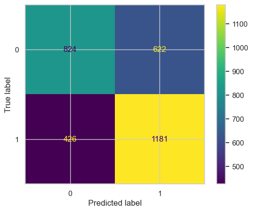

```python
# Generate array of values for confusion matrix
cm = confusion_matrix(y_test, rf_preds, labels=rf1.classes_)

# Plot confusion matrix
disp = ConfusionMatrixDisplay(confusion_matrix=cm,
                             display_labels=rf1.classes_,
                             )
disp.plot(values_format='');
```

# Create a feature importance plot

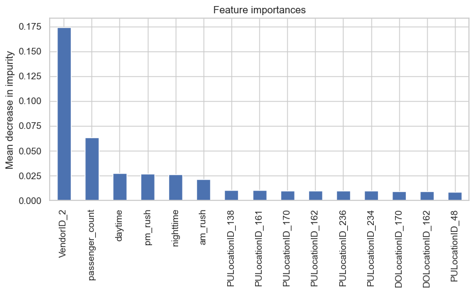

```python
importances = rf1.best_estimator_.feature_importances_
rf_importances = pd.Series(importances, index=X_test.columns)
rf_importances = rf_importances.sort_values(ascending=False)[:15]

fig, ax = plt.subplots(figsize=(8,5))
rf_importances.plot.bar(ax=ax)
ax.set_title('Feature importances')
ax.set_ylabel('Mean decrease in impurity')
fig.tight_layout();
```